# Exercise 7: Neighborhood Matrices and Autocorrelation

Introduction to Geospatial Techniques for Social Scientists in R

Author

Stefan Jünger & Dennis Abel

Thus far, we have only used Queen neighborhood matrices with our data. Let’s use this exercise to try out different variations. First of all, run the code below to compile the data that were also used in the lecture.

```r
# Load relevant packages
library(dplyr)
library(ggplot2)
library(sf)
library(terra)
library(tmap)

# Load voting districts and results
voting_districts <-
  sf::st_read("./data/Stimmbezirk.shp") |>
  dplyr::mutate(
    district_id = as.numeric(nummer)
  ) |>
  dplyr::select(district_id, Shape_Area, geometry)

btw21_votes <-
  glue::glue(
    "https://www.stadt-koeln.de/wahlen/bundestagswahl/09-2021/praesentation/\\
    Open-Data-Bundestagswahl476.csv"
  ) |>
  readr::read_csv2() |>
  dplyr::mutate(
    district_id = as.numeric(`gebiet-nr`),
    valid_votes = `F`,
    cdu_share = (F1 / valid_votes) * 100,
    spd_share = (F2 / valid_votes) * 100,
    fdp_share = (F3 / valid_votes) * 100,
    afd_share = (F4 / valid_votes) * 100,
    greens_share = (F5 / valid_votes) * 100,
    linke_share = (F6 / valid_votes) * 100,
    .keep = "none"
  )

btw21_votes <- btw21_votes |>
  dplyr::rowwise() |>
  dplyr::mutate(
    highest_vote = factor(
      sub(
        "_share$",
        "",
        names(dplyr::pick(dplyr::ends_with("_share")))[
          order(
            dplyr::c_across(dplyr::ends_with("_share")),
            decreasing = TRUE
          )[1]
        ]
      )
    ),
    second_highest_vote = factor(
      sub(
        "_share$",
        "",
        names(dplyr::pick(dplyr::ends_with("_share")))[
          order(
            dplyr::c_across(dplyr::ends_with("_share")),
            decreasing = TRUE
          )[2]
        ]
      )
    )
  ) |>
  dplyr::ungroup()

election_results <-
  dplyr::left_join(
    voting_districts,
    btw21_votes,
    by = "district_id"
  )

# Load additional raster data
immigrants_cologne <- terra::rast("./data/immigrants_cologne.tif")
inhabitants_cologne <- terra::rast("./data/inhabitants_cologne.tif")

immigrants_cologne  <- terra::subst(immigrants_cologne,  from = -9, to = NA)
inhabitants_cologne <- terra::subst(inhabitants_cologne, from = -9, to = NA)

immigrant_share_cologne <- (immigrants_cologne / inhabitants_cologne)*100

age_rast <- terra::rast("./data/census22_age_avg.tif")
rent_rast <- terra::rast("./data/census22_rent_avg.tif")

# Extract
election_results <-
  election_results |>
  dplyr::mutate(
    immigrant_share =
      exactextractr::exact_extract(
        immigrant_share_cologne, election_results, 'mean', progress = FALSE
      ),
    inhabitants =
      exactextractr::exact_extract(
        inhabitants_cologne, election_results, 'mean', progress = FALSE
      ),
    age_avg =
      exactextractr::exact_extract(
        age_rast, election_results, 'mean', progress = FALSE
      ),
    rent_avg =
      exactextractr::exact_extract(
        rent_rast, election_results, 'mean', progress = FALSE
      )
  )
```

### Exercises

**Note🏋 Exercise 1**

As in the lecture, create a neighborhood (weight) matrix, but this time, do it for Queen and Rook neighborhoods. Also, apply a row normalization.

**Caution💡 Tip**

You could either use the `sdep` package with its function `spdep::poly2nb()` or the more modern approach of the `sfdep` package using the function `sfdep::st_contiguity()`. In both cases, you must set the option `queen = FALSE` for Rook neighborhoods.

**Note🏋 Exercise 2**

We have not used them, but you can also create distance-based weight matrices. Use the package of your choice again and create weights for a distance between 0 and 5000 meters. Use again row-normalization.

You must also convert the polygon data to point coordinates for this exercise. We’d propose to use the centroids for this task:

`election_results_centroids <- sf::st_centroid(election_results)`

Use a map to corroborate this conversion was successful.

**Caution💡 Tip**

If you use `spdep`, use the function `spdep::dnearneigh()`; if you use `sfdep`, use the function `sfdep::st_dist_band()`.

**Note🏋 Exercise 3**

Now, let’s see how these different spatial weights perform in an analysis. Calculate Moran’s I and Geary’s C for each one of the weights and report their results for the variable spd_share.

**Caution💡 Tip**

It is essential to know which path you have taken before – using `spdep` and `sfdep` – as it determines how you solve this exercise.

### Solutions

**Tip✅ Solution 1**

```r
# spdep
queen_neighborhood <-
  spdep::poly2nb(
    election_results,
    queen = TRUE
  )

queen_W <- spdep::nb2listw(queen_neighborhood, style = "W")

rook_neighborhood <-
  spdep::poly2nb(
    election_results,
    queen = FALSE
  )

rook_W <- spdep::nb2listw(rook_neighborhood, style = "W")

# sfdep
election_results <-
  election_results |>
  dplyr::mutate(
    queen_neighborhood = sfdep::st_contiguity(election_results, queen = TRUE),
    queen_W = sfdep::st_weights(queen_neighborhood),
    rook_neighborhood = sfdep::st_contiguity(election_results, queen = FALSE),
    rook_W = sfdep::st_weights(rook_neighborhood)
  )
```

**Tip✅ Solution 2**

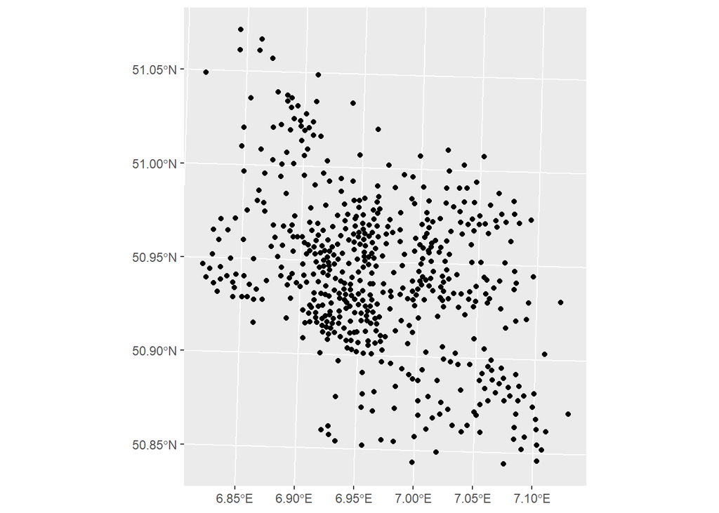

```r
# convert to centroids
election_results_centroids <- sf::st_centroid(election_results)
ggplot() +
  geom_sf(data = election_results_centroids, color = "black")
```

```r
# spdep
distance_neighborhood_5000 <-
  spdep::dnearneigh(election_results_centroids, 0, 5000)

distance_neighborhood_5000_W <-
  spdep::nb2listw(distance_neighborhood_5000, style = "W")

# sfdep
election_results_centroids <-
  election_results_centroids |>
  dplyr::mutate(
    neighbors_5000 = sfdep::st_dist_band(election_results_centroids, 0, 5000),
    weights_5000 = sfdep::st_weights(neighbors_5000)
  )
```

**Tip✅ Solution 3**

```r
spdep::moran.test(election_results$spd_share, listw = queen_W)
```

```
    Moran I test under randomisation

data:  election_results$spd_share
weights: queen_W

Moran I statistic standard deviate = 20.869, p-value < 2.2e-16
alternative hypothesis: greater
sample estimates:
Moran I statistic       Expectation          Variance
     0.5404799889     -0.0018450185      0.0006753055
```

```r
spdep::moran.test(election_results$spd_share, listw = rook_W)
```

```
    Moran I test under randomisation

data:  election_results$spd_share
weights: rook_W

Moran I statistic standard deviate = 20.332, p-value < 2.2e-16
alternative hypothesis: greater
sample estimates:
Moran I statistic       Expectation          Variance
     0.5444447649     -0.0018450185      0.0007219029
```

```r
spdep::moran.test(
  election_results_centroids$spd_share,
  listw = distance_neighborhood_5000_W
)
```

```
    Moran I test under randomisation

data:  election_results_centroids$spd_share
weights: distance_neighborhood_5000_W

Moran I statistic standard deviate = 45.601, p-value < 2.2e-16
alternative hypothesis: greater
sample estimates:
Moran I statistic       Expectation          Variance
     2.494222e-01     -1.845018e-03      3.036107e-05
```

```r
spdep::geary.test(election_results$spd_share, listw = queen_W)
```

```
    Geary C test under randomisation

data:  election_results$spd_share
weights: queen_W

Geary C statistic standard deviate = 19.232, p-value < 2.2e-16
alternative hypothesis: Expectation greater than statistic
sample estimates:
Geary C statistic       Expectation          Variance
     0.4556471765      1.0000000000      0.0008011317
```

```r
spdep::geary.test(election_results$spd_share, listw = rook_W)
```

```
    Geary C test under randomisation

data:  election_results$spd_share
weights: rook_W

Geary C statistic standard deviate = 18.947, p-value < 2.2e-16
alternative hypothesis: Expectation greater than statistic
sample estimates:
Geary C statistic       Expectation          Variance
     0.4477206733      1.0000000000      0.0008496821
```

```r
spdep::geary.test(
  election_results_centroids$spd_share,
  listw = distance_neighborhood_5000_W
)
```

```
    Geary C test under randomisation

data:  election_results_centroids$spd_share
weights: distance_neighborhood_5000_W

Geary C statistic standard deviate = 31.847, p-value < 2.2e-16
alternative hypothesis: Expectation greater than statistic
sample estimates:
Geary C statistic       Expectation          Variance
     7.535200e-01      1.000000e+00      5.990103e-05
```

```r
# sfdep
library(magrittr)
election_results %$%
  sfdep::global_moran_test(spd_share, queen_neighborhood, queen_W)
```

```
    Moran I test under randomisation

data:  x
weights: listw

Moran I statistic standard deviate = 20.869, p-value < 2.2e-16
alternative hypothesis: greater
sample estimates:
Moran I statistic       Expectation          Variance
     0.5404799889     -0.0018450185      0.0006753055
```

```r
election_results %$%
  sfdep::global_moran_test(spd_share, rook_neighborhood, rook_W)
```

```
    Moran I test under randomisation

data:  x
weights: listw

Moran I statistic standard deviate = 20.332, p-value < 2.2e-16
alternative hypothesis: greater
sample estimates:
Moran I statistic       Expectation          Variance
     0.5444447649     -0.0018450185      0.0007219029
```

```r
election_results_centroids %$%
  sfdep::global_moran_test(spd_share, neighbors_5000, weights_5000)
```

```
    Moran I test under randomisation

data:  x
weights: listw

Moran I statistic standard deviate = 45.601, p-value < 2.2e-16
alternative hypothesis: greater
sample estimates:
Moran I statistic       Expectation          Variance
     2.494222e-01     -1.845018e-03      3.036107e-05
```

```r
election_results %$%
  sfdep::global_c_test(spd_share, queen_neighborhood, queen_W)
```

```
    Geary C test under randomisation

data:  x
weights: listw

Geary C statistic standard deviate = 19.232, p-value < 2.2e-16
alternative hypothesis: Expectation greater than statistic
sample estimates:
Geary C statistic       Expectation          Variance
     0.4556471765      1.0000000000      0.0008011317
```

```r
election_results %$%
  sfdep::global_c_test(spd_share, rook_neighborhood, rook_W)
```

```
    Geary C test under randomisation

data:  x
weights: listw

Geary C statistic standard deviate = 18.947, p-value < 2.2e-16
alternative hypothesis: Expectation greater than statistic
sample estimates:
Geary C statistic       Expectation          Variance
     0.4477206733      1.0000000000      0.0008496821
```

```r
election_results_centroids %$%
  sfdep::global_c_test(spd_share, neighbors_5000, weights_5000)
```

```
    Geary C test under randomisation

data:  x
weights: listw

Geary C statistic standard deviate = 31.847, p-value < 2.2e-16
alternative hypothesis: Expectation greater than statistic
sample estimates:
Geary C statistic       Expectation          Variance
     7.535200e-01      1.000000e+00      5.990103e-05
```

**Tip✅ Solution 4**

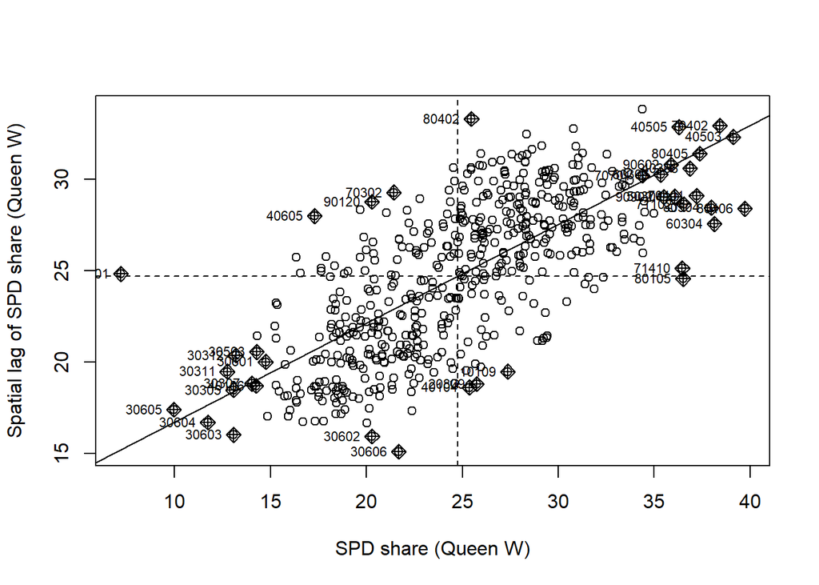

```r
spdep::moran.plot(
  x = election_results$spd_share,
  listw = queen_W,
  labels = election_results$district_id,
  xlab = "SPD share (Queen W)",
  ylab = "Spatial lag of SPD share (Queen W)"
)
```

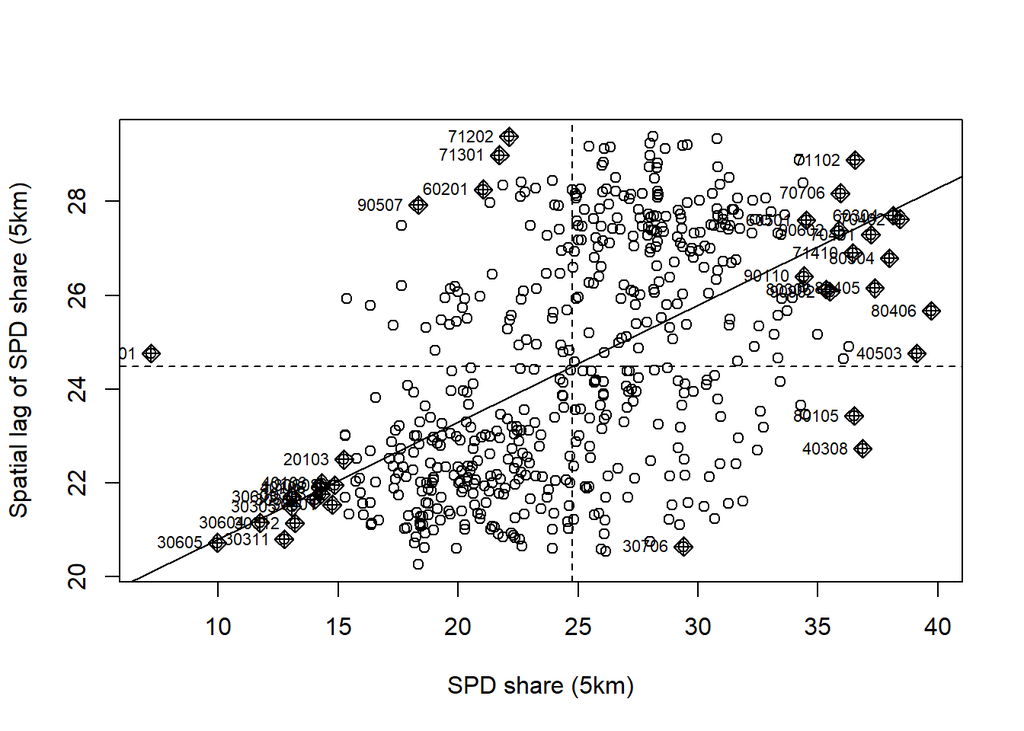

```r
spdep::moran.plot(
  x = election_results_centroids$spd_share,
  listw = distance_neighborhood_5000_W,
  labels = election_results_centroids$district_id,
  xlab = "SPD share (5km)",
  ylab = "Spatial lag of SPD share (5km)"
)
```